# *igblastr* overview

Hervé Pagès, Kellie MacPhee and Ollivier Hyrien

Fred Hutch Cancer Center, Seattle, WA

Compiled 15 July 2026; Modified 15 July 2026

#### Package

igblastr 1.3.14

# 1 Introduction

The Immunoglobulin Basic Local Alignment Search Tool (IgBLAST) is a specialized bioinformatics tool developed by the National Center for Biotechnology Information (NCBI) for the analysis of B-cell receptor (BCR) and T-cell receptor (TCR) sequences (Ye et al., 2013). IgBLAST performs sequence alignment and annotation, with key outputs including germline V, D, and J gene assignments; characterization of somatic hypermutations introduced during affinity maturation; identification of complementarity-determining regions (CDR1–CDR3), framework regions (FWR1–FWR4), and isotype; and both nucleotide- and amino acid-level alignments. These outputs form the basis for many downstream analyses of BCR and TCR repertoires, including clonotype identification, lineage tracing, and repertoire feature characterization.

*igblastr* is an R/Bioconductor package that provides functions to conveniently install and use a local IgBLAST installation from within R. In addition to performing standard IgBLAST annotation, it offers additional BCR and TCR sequence annotation capabilities, returning all results in AIRR-style format.

The package is designed to make it as easy as possible to run IgBLAST in R by streamlining the installation of IgBLAST and IgBLAST-compatible *germline databases*. In particular, these installations can be performed with a single function call, do not require root access, and can persist across R sessions. Furthermore, when installing IgBLAST-compatible *germline databases*, the package will also automatically generate IgBLAST-compatible annotations for the V and J alleles included in the database. These automatic annotations can then be used as replacements for the *internal data* and *auxiliary data* provided by IgBLAST. Note that the latter can be outdated and/or incomplete, or simply missing when installing a *germline database* for a non-IgBLAST organism (IgBLAST only supports human, mouse, rabbit, rat, and rhesus monkey out of the box).

The main function in the package is `igblastn()`, a wrapper to the `igblastn` *standalone executable* included in IgBLAST. In addition to `igblastn()`, the package provides several other features, including:

- The `install_igblast()` function to conveniently download and install a pre-compiled IgBLAST from NCBI.
- A set of built-in IgBLAST-compatible *germline databases* from [OGRDB](https://ogrdb.airr-community.org/), the AIRR Community’s Open Germline Receptor Database.
- Functions to download and install IgBLAST-compatible *germline databases* from the [IMGT/V-QUEST download site](https://www.imgt.org/download/V-QUEST/), and to configure them for use with `igblastn()`.
- The `install_custom_germline_db()` function to install an IgBLAST-compatible *germline database* from user-supplied germline gene allele sequences.
- Functions to compute, access, and manipulate IgBLAST *internal data* and *auxiliary data*.
- A set of built-in IgBLAST-compatible constant region (C-region) databases from IMGT/V-QUEST.
- Utility functions to parse the results returned by `igblastn()`.
- The `igbrowser()` function to vizualize the annotated sequences in a browser.
- The `percent_mutation()` function to compute the percent mutation in the V, D, J segments of a set of BCR or TCR sequences.
- Utility functions to download data from [OAS](https://opig.stats.ox.ac.uk/webapps/oas/), the Observed Antibody Space database, and prepare it for use with IgBLAST.

Useful links:

- IgBLAST is described at https://pubmed.ncbi.nlm.nih.gov/23671333/
- IgBLAST web interface: https://www.ncbi.nlm.nih.gov/igblast/
- OGRDB: https://ogrdb.airr-community.org/
- IMGT/V-QUEST download site: https://www.imgt.org/download/V-QUEST/

Please use https://github.com/HyrienLab/igblastr/issues to report bugs, provide feedback, request features (etc) about *igblastr*.

# 2 Install and load the package

Like any Bioconductor package, *igblastr* should be installed with `BiocManager::install()`:

```r
if (!require("BiocManager", quietly=TRUE))
    install.packages("BiocManager")
BiocManager::install("igblastr")
```

`BiocManager::install()` will take care of installing the package dependencies that are missing.

To load *igblastr* into your R session, run:

```r
library(igblastr)
```

# 3 Install and check IgBLAST

## 3.1 Install IgBLAST

If IgBLAST is already installed on your system, you can tell *igblastr* to use it by setting the environment variable `IGBLAST_ROOT` to the path of your IgBLAST installation. See `?IGBLAST_ROOT` for more information.

Otherwise, simply call `install_igblast()` to install the latest version of IgBLAST. As of March 2025, NCBI provides pre-compiled versions of IgBLAST for Linux, Windows, Intel Mac and Mac Silicon. `install_igblast()` will automatically download the appropriate pre-compiled version of IgBLAST for your platform from the NCBI FTP site, and install it in a location that will be remembered across R sessions.

```r
if (!has_igblast())
    install_igblast()
```

See `?install_igblast` for more information.

Note that we use `has_igblast()` to avoid reinstalling IgBLAST if *igblastr* already has access to a working IgBLAST installation.

## 3.2 Check IgBLAST

To display basic information about the IgBLAST installation used by *igblastr*, run:

```r
igblast_info()
```

```
## igblast_root:        /home/hpages/.cache/R/igblastr/igblast_roots/1.22.0
## igblast_build:       igblast 1.22.0, build Oct 11 2023 16:06:20
## igblastn_version:    1.22.0
## makeblastdb_version: 2.15.0+
## OS/arch:             Linux/x86_64
## igblast_organisms:   human, mouse, rabbit, rat, rhesus_monkey
```

# 4 Install and select an IgBLAST-compatible germline database

To analyze BCR or TCR sequences, IgBLAST aligns each of them to a reference set of germline V, D, and J gene allele sequences. Therefore, in order to run IgBLAST, we need access to an IgBLAST-compatible *germline database* against which the sequence to analyze will be aligned. Note that such database actually consists of three separate BLAST databases bundled together: the V-, D-, and J-region BLAST databases.

## 4.1 Built-in germline databases

The *igblastr* package includes a set of built-in IgBLAST-compatible *germline databases* for human, mouse, rainbow trout, and rhesus monkey that were obtained from the OGRDB database (AIRR community). To get the list of built-in *germline databases*, run:

```r
list_germline_dbs(builtin.only=TRUE)
```

```
##  db_name                                       V  D  J intdata auxdata
##  _OGRDB.human.IGH+IGK+IGL.202410             342 31 23    TRUE    TRUE
##  _OGRDB.human.IGH+IGK+IGL.202410.src         354 33 24    TRUE    TRUE
##  _OGRDB.human.IGH+IGK+IGL.202605             367 31 23    TRUE    TRUE
##  _OGRDB.human.IGH+IGK+IGL.202605.src         379 33 24    TRUE    TRUE
##  _OGRDB.mouse.CAST_EiJ.IGH+IGK+IGL.202603    184  9 22    TRUE    TRUE
##  _OGRDB.mouse.LEWES_EiJ.IGH+IGK+IGL.202603   169 11 22    TRUE    TRUE
##  _OGRDB.mouse.MSM_MsJ.IGH+IGK+IGL.202603     172  9 22    TRUE    TRUE
##  _OGRDB.mouse.NOD_ShiLtJ.IGH+IGK+IGL.202205  149  9 22    TRUE    TRUE
##  _OGRDB.mouse.PWD_PhJ.IGH+IGK+IGL.202410     184 10 22    TRUE    TRUE
##  _OGRDB.rainbow_trout.IGH.202606              81 26 18    TRUE    TRUE
##  _OGRDB.rhesus_monkey.IGH+IGK+IGL.202602    2294 72 39    TRUE    TRUE
```

The last part of the database name indicates the date of the download in YYYYMM format.

The `intdata` and `auxdata` columns indicate whether a database includes its own annotations for the germline V alleles (`intdata` column) and germline J alleles (`auxdata` column). More on this in the “Internal data and auxiliary data” section below.

If the BCR sequences to analyze are from one of the OGRDB organisms then we can already select the appropriate database with `use_germline_db()` and skip the subsection below.

## 4.2 Install additional IgBLAST-compatible germline databases

AIRR/OGRDB and IMGT/V-QUEST are two providers of germline datasets that can be used to create IgBLAST-compatible *germline databases*. If, for any reason, none of the built-in AIRR/OGRDB *germline databases* is suitable (e.g., the sequences to analyze are not from human, mouse, rainbow trout, or rhesus monkey), then we can use `install_IMGT_germline_db()` to create and install additional IgBLAST-compatible *germline databases*. Below, we show how to create and install an IgBLAST-compatible *germline database* from germline V, D, and J gene sequences available on IMGT/V-QUEST download site.

### 4.2.1 Install an IgBLAST-compatible germline database from IMGT/V-QUEST

First, we list the most recent IMGT/V-QUEST releases:

```r
head(list_IMGT_releases())
```

```
## [1] "202625-4" "202623-4" "202616-1" "202614-2" "202612-4" "202611-4"
```

The organisms included in release 202614-2 are:

```r
list_IMGT_organisms("202614-2")
```

```
##  [1] "Aotus_nancymaae"          "Bos_taurus"
##  [3] "Camelus_dromedarius"      "Canis_lupus_familiaris"
##  [5] "Capra_hircus"             "Chondrichthyes"
##  [7] "Danio_rerio"              "Equus_caballus"
##  [9] "Felis_catus"              "Gadus_morhua"
## [11] "Gallus_gallus"            "Gorilla_gorilla_gorilla"
## [13] "Heterocephalus_glaber"    "Homo_sapiens"
## [15] "Ictalurus_punctatus"      "Lemur_catta"
## [17] "Macaca_fascicularis"      "Macaca_mulatta"
## [19] "Mus_musculus"             "Mus_musculus_C57BL6J"
## [21] "Mustela_putorius_furo"    "Neogale_vison"
## [23] "Nonhuman_primates"        "Oncorhynchus_mykiss"
## [25] "Ornithorhynchus_anatinus" "Oryctolagus_cuniculus"
## [27] "Ovis_aries"               "Pan_troglodytes"
## [29] "Pongo_abelii"             "Pongo_pygmaeus"
## [31] "Rattus_norvegicus"        "Salmo_salar"
## [33] "Sus_scrofa"               "Teleostei"
## [35] "Tursiops_truncatus"       "Vicugna_pacos"
```

Next, we create and install an IgBLAST-compatible *germline database* from the human germline V, D, and J gene sequences available in IMGT/V-QUEST release 202614-2:

```r
install_IMGT_germline_db("202614-2", organism="Homo sapiens")
```

See `?install_IMGT_germline_db` for more information.

### 4.2.2 Install an IgBLAST-compatible germline database from user-supplied gene allele sequences

The *igblastr* package provides the `install_custom_germline_db()` function to create and install an IgBLAST-compatible *germline database* from a set of user-supplied FASTA files containing germline V/D/J gene allele nucleotide sequences.

See `?install_custom_germline_db` for more information.

## 4.3 Select the germline database to use with igblastn()

Finally, we select the newly installed database as the *germline database* to use with `igblastn()`. For example, assuming that the sequences to analyze are human antibody sequences:

```r
use_germline_db("IMGT-202614-2.Homo_sapiens.IGH+IGK+IGL")
```

```
##   CONDITIONS OF USE AND LICENSE: The IMGT data is provided to the academic
##   users and NPO's (Not for Profit Organization(s)) under the CC BY-NC-ND 4.0
##   license. See https://creativecommons.org/licenses/by-nc-nd/4.0/. Any other
##   use of IMGT material, from the private sector, needs a financial arrangement
##   with CNRS.
##
##   To suppress this message, use:
##     suppressMessages(use_germline_db("IMGT-202614-2.Homo_sapiens.IGH+IGK+IGL"))
```

See `?use_germline_db` for more information.

To see the full list of cached *germline databases*:

```r
list_germline_dbs()
```

```
##  db_name                                       V  D  J intdata auxdata
##  _OGRDB.human.IGH+IGK+IGL.202410             342 31 23    TRUE    TRUE
##  _OGRDB.human.IGH+IGK+IGL.202410.src         354 33 24    TRUE    TRUE
##  _OGRDB.human.IGH+IGK+IGL.202605             367 31 23    TRUE    TRUE
##  _OGRDB.human.IGH+IGK+IGL.202605.src         379 33 24    TRUE    TRUE
##  _OGRDB.mouse.CAST_EiJ.IGH+IGK+IGL.202603    184  9 22    TRUE    TRUE
##  _OGRDB.mouse.LEWES_EiJ.IGH+IGK+IGL.202603   169 11 22    TRUE    TRUE
##  _OGRDB.mouse.MSM_MsJ.IGH+IGK+IGL.202603     172  9 22    TRUE    TRUE
##  _OGRDB.mouse.NOD_ShiLtJ.IGH+IGK+IGL.202205  149  9 22    TRUE    TRUE
##  _OGRDB.mouse.PWD_PhJ.IGH+IGK+IGL.202410     184 10 22    TRUE    TRUE
##  _OGRDB.rainbow_trout.IGH.202606              81 26 18    TRUE    TRUE
##  _OGRDB.rhesus_monkey.IGH+IGK+IGL.202602    2294 72 39    TRUE    TRUE
##  IMGT-202614-2.Homo_sapiens.IGH+IGK+IGL      730 48 35    TRUE    TRUE *
```

Note that the asterisk (`*`) displayed at the far right of the output from `list_germline_dbs()` indicates the currently selected *germline database* (you may need to scroll horizontally to see the asterisk).

See `?list_germline_dbs` for more information.

# 5 Internal data and auxiliary data

Note that the newly installed *germline database* (`IMGT-202614-2.Homo_sapiens.IGH+IGK+IGL`) includes its own *internal data* and *auxiliary data*, as reported in the `intdata` and `auxdata` columns.

## 5.1 What are the *internal data* and *auxiliary data*?

The `intdata` and `auxdata` columns indicate whether a database includes annotations for the germline V alleles (`intdata` column) and germline J alleles (`auxdata` column). These annotations consist of reporting the coding frame start position and FWR/CDR boundaries on the V and J sequences. Note that the FWR/CDR boundaries on the V sequences are also known as the V gene delineations. For the J sequences, the only FWR/CDR boundary is the CDR3/FWR4 boundary.

When analyzing BCR or TCR sequences with IgBLAST, the latter needs access to this information in order to annotate the former. In IgBLAST’s terminology, the annotations for the germline V and J alleles are called *internal data* and *auxiliary data*, respectively.

## 5.2 IgBLAST-provided internal/auxiliary data

IgBLAST provides *internal data* and *auxiliary data* for 5 organisms: human, mouse, rabbit, rat, and rhesus monkey. We’ll sometimes refer to these organisms as IgBLAST organisms.

This data can be accessed with `load_intdata()` and `load_auxdata()`:

```r
head(load_intdata("human"))
```

```
##   allele_name fwr1_start fwr1_end cdr1_start cdr1_end fwr2_start fwr2_end
## 1          A1          1       78         79      111        112      162
## 2         A10          1       78         79       96         97      147
## 3         A11          1       78         79       99        100      150
## 4         A14          1       78         79       96         97      147
## 5         A17          1       78         79      111        112      162
## 6        A18b          1       78         79      111        112      162
##   cdr2_start cdr2_end fwr3_start fwr3_end chain_type coding_frame_start
## 1        163      171        172      279         VK                  0
## 2        148      156        157      264         VK                  0
## 3        151      159        160      267         VK                  0
## 4        148      156        157      264         VK                  0
## 5        163      171        172      279         VK                  0
## 6        163      171        172      279         VK                  0
```

```r
head(load_auxdata("human"))
```

```
##   allele_name coding_frame_start chain_type cdr3_end extra_bps
## 1    IGHJ1*01                  0         JH       17         1
## 2   IGHJ1P*01                  2         JH       NA        NA
## 3    IGHJ2*01                  1         JH       18         1
## 4   IGHJ2P*01                  0         JH       NA        NA
## 5    IGHJ3*01                  1         JH       15         1
## 6    IGHJ3*02                  1         JH       15         1
```

See `?load_intdata` and `?load_auxdata` for more information.

However, this data doesn’t get updated on a regular basis by the NCBI folks, and can be incomplete or out-of-sync with the germline V and J alleles provided by AIRR/OGRDB or IMGT/V-QUEST.

## 5.3 igblastr-generated internal/auxiliary data

Unlike the *internal data* and *auxiliary data* provided by IgBLAST, the *internal data* and *auxiliary data* included in a *germline database* is generated by *igblastr*, and is guaranteed to be complete and in sync with the germline V and J alleles in the database.

This data can also be accessed with `load_intdata()` and `load_auxdata()`:

```r
head(load_intdata("IMGT-202614-2.Homo_sapiens.IGH+IGK+IGL"))
```

```
##   allele_name fwr1_start fwr1_end cdr1_start cdr1_end fwr2_start fwr2_end
## 1 IGHV1-18*01          1       75         76       99        100      150
## 2 IGHV1-18*02          1       75         76       99        100      150
## 3 IGHV1-18*03          1       75         76       99        100      150
## 4 IGHV1-18*04          1       75         76       99        100      150
## 5  IGHV1-2*01          1       75         76       99        100      150
## 6  IGHV1-2*02          1       75         76       99        100      150
##   cdr2_start cdr2_end fwr3_start fwr3_end chain_type coding_frame_start
## 1        151      174        175      288         VH                  0
## 2        151      174        175      288         VH                  0
## 3        151      174        175      288         VH                  0
## 4        151      174        175      288         VH                  0
## 5        151      174        175      288         VH                  0
## 6        151      174        175      288         VH                  0
```

```r
head(load_auxdata("IMGT-202614-2.Homo_sapiens.IGH+IGK+IGL"))
```

```
##   allele_name coding_frame_start chain_type cdr3_end extra_bps
## 1    IGHJ1*01                  0         JH       17         1
## 2    IGHJ2*01                  1         JH       18         1
## 3    IGHJ3*01                  1         JH       15         1
## 4    IGHJ3*02                  1         JH       15         1
## 5    IGHJ4*01                  2         JH       13         1
## 6    IGHJ4*02                  2         JH       13         1
```

See `?load_intdata` and `?load_auxdata` for more information.

### 5.3.1 How is this data generated?

For the built-in OGRDB *germline databases* (the `_OGRDB.*` databases), the *internal data* and *auxiliary data* is provided by AIRR/OGRDB.

For a *germline database* created with `install_IMGT_germline_db()` like `IMGT-202614-2.Homo_sapiens.IGH+IGK+IGL`:

- *internal data*: The V gene delineations are inferred from the gaps in the nucleotide sequences of the V alleles provided by IMGT/V-QUEST.
- *auxiliary data*: The procedure to generate this data is described in the *igblastr* Wiki [here](https://github.com/HyrienLab/igblastr/wiki/Auxiliary-data-in-igblastr#igblastr-generated-auxiliary-data).

### 5.3.2 How to use the igblastr-generated internal/auxiliary data with igblastr?

This happens automatically!

More precisely, if a *germline database* includes its own *internal data* and *auxiliary data*, then the `igblastn()` function will use this data instead of the *internal data* and *auxiliary data* provided by IgBLAST.

See documentation of the `custom_internal_data` and `auxiliary_data` arguments in `?igblastn` for more information.

# 6 Select a constant region database (optional)

The `igblastn` *standalone executable* included in IgBLAST can also use constant region (C-region) sequences for sequence annotation. As with the germline V, D, and J gene allele sequences, the C-region sequences are expected to originate from the same organism as the sequences to analyze, and must likewise be formatted as a BLAST database. We will refer to this database as the C-region database.

The *igblastr* package includes built-in C-region databases for human, mouse, rabbit, rat, and rhesus monkey, obtained from IMGT/V-QUEST. The available databases can be listed using:

```r
list_c_region_dbs()
```

```
##  db_name                                      C
##  _IMGT.human.IGH+IGK+IGL.202605             180
##  _IMGT.human.TRA+TRB+TRG+TRD.202605          23
##  _IMGT.mouse.IGH+IGK+IGL.202605              64
##  _IMGT.mouse.TRA+TRB+TRG+TRD.202605          13
##  _IMGT.rabbit.IGH+IGK+IGL.202605             50
##  _IMGT.rabbit.TRA+TRB+TRG+TRD.202605          6
##  _IMGT.rat.IGH+IGK+IGL.202605                25
##  _IMGT.rhesus_monkey.IGH+IGK+IGL.202605      44
##  _IMGT.rhesus_monkey.TRA+TRB+TRG+TRD.202605  10
```

The last part of the database name indicates the date of the download in YYYYMM format.

If the sequences to analyze are from one of the organisms listed above, we can select the appropriate C-region database using `use_c_region_db()`. For example, assuming that the sequences to analyze are human antibody sequences:

```r
use_c_region_db("_IMGT.human.IGH+IGK+IGL.202605")
```

```
##   CONDITIONS OF USE AND LICENSE: The IMGT data is provided to the academic
##   users and NPO's (Not for Profit Organization(s)) under the CC BY-NC-ND 4.0
##   license. See https://creativecommons.org/licenses/by-nc-nd/4.0/. Any other
##   use of IMGT material, from the private sector, needs a financial arrangement
##   with CNRS.
##
##   To suppress this message, use:
##     suppressMessages(use_c_region_db("_IMGT.human.IGH+IGK+IGL.202605"))
```

Calling `list_c_region_dbs()` again should display an asterisk (`*`) at the far right of the output, indicating the currently selected C-region database.

See `?list_c_region_dbs` for more information.

# 7 Use igblastn()

Now that we have selected the germline and C-region databases to use with `igblastn()`, we are almost ready to call `igblastn()` to perform the alignment.

## 7.1 Prepare the query sequences

In the context of sequence analysis with IgBLAST, we refer to the set of sequences to analyze as the *query sequences*.

The *igblastr* package includes a FASTA file containing 8,437 paired heavy- and light-chain human antibody sequences (16,874 individual sequences) retrieved from OAS. This BCR sequencing dataset will serve as the *query sequences* that we analyze in this section.

To get the path to the *query sequences*, use:

```r
query <- system.file(package="igblastr", "extdata",
                     "BCR", "1279067_1_Paired_sequences.fasta.gz")
```

The *igblastr* package also includes a JSON file containing metadata describing this BCR sequencing dataset:

```r
json <- system.file(package="igblastr", "extdata",
                    "BCR", "1279067_1_Paired_All.json")
query_metadata <- jsonlite::fromJSON(json)
query_metadata
```

```
## $Run
## [1] 1279067
##
## $Link
## [1] "https://doi.org/10.1038/s41586-022-05371-z"
##
## $Author
## [1] "Jaffe et al., 2022"
##
## $Species
## [1] "human"
##
## $Age
## [1] 38
##
## $BSource
## [1] "PBMC"
##
## $BType
## [1] "Memory-B-Cells"
##
## $Vaccine
## [1] "None"
##
## $Disease
## [1] "None"
##
## $Subject
## [1] "Donor-3"
##
## $Longitudinal
## [1] "no"
##
## $`Unique sequences`
## [1] 8437
##
## $Isotype
## [1] "All"
##
## $Chain
## [1] "Paired"
```

The 8,437 paired sequences come from memory B cells isolated from peripheral blood mononuclear cell (PBMC) samples of a single human donor (age 38) with no known disease or vaccination history. The source for these sequences is the Jaffe et al. (2022) study; the DOI link to the publication is provided above.

## 7.2 Call igblastn() on the query sequences

To analyze our *query sequences*, we’re going to use the `igblastn()` function. This is a wrapper to the `igblastn` *standalone executable* included in IgBLAST.

Before calling `igblastn()`, we first check the selected databases by calling `use_germline_db()` and `use_c_region_db()` with no arguments:

```r
use_germline_db()
```

```
## [1] "IMGT-202614-2.Homo_sapiens.IGH+IGK+IGL"
```

```r
use_c_region_db()
```

```
## [1] "_IMGT.human.IGH+IGK+IGL.202605"
```

Now, let’s call `igblastn()`. Since we are only interested in the best V alignment for each *query sequence*, we set `num_alignments_V` to 1. Analyzing this set of 16,874 BCR sequences may take up to around 3 min on a standard laptop:

```r
AIRR_df <- igblastn(query, num_alignments_V=1)
```

By default, the result is an *AIRR-formatted* tibble, that is, a tibble with one row per *query sequence* and many columns:

```r
AIRR_df
```

```
## # A tibble: 16,874 × 111
##    sequence_id    sequence sequence_aa locus stop_codon vj_in_frame v_frameshift
##    <chr>          <chr>    <chr>       <chr> <lgl>      <lgl>       <lgl>
##  1 heavy_chain_A… ACAACCA… QVQLVQSGSE… IGH   FALSE      TRUE        FALSE
##  2 light_chain_A… TGAGCGC… QSVLTQPPSV… IGL   FALSE      TRUE        FALSE
##  3 heavy_chain_A… ACTTTCT… QVQLQESGPG… IGH   FALSE      TRUE        FALSE
##  4 light_chain_A… GAGGAGT… DIQMTQSPSS… IGK   FALSE      TRUE        FALSE
##  5 heavy_chain_A… GGGATCA… QVQLVQSGAE… IGH   FALSE      TRUE        FALSE
##  6 light_chain_A… GCTGGGG… QSALTQPPSA… IGL   FALSE      TRUE        FALSE
##  7 heavy_chain_A… GGAGCCC… EVQLVESGGG… IGH   FALSE      TRUE        FALSE
##  8 light_chain_A… GGGGGCT… QSALTQPASV… IGL   FALSE      TRUE        FALSE
##  9 heavy_chain_A… ATACTTT… QVQLQESGPG… IGH   FALSE      TRUE        FALSE
## 10 light_chain_A… GAGCTAC… DIVMTQSPDS… IGK   FALSE      TRUE        FALSE
## # ℹ 16,864 more rows
## # ℹ 104 more variables: productive <lgl>, rev_comp <lgl>, complete_vdj <lgl>,
## #   d_frame <lgl>, v_call <chr>, d_call <chr>, j_call <chr>, c_call <chr>,
## #   sequence_alignment <chr>, germline_alignment <chr>,
## #   sequence_alignment_aa <chr>, germline_alignment_aa <chr>,
## #   v_alignment_start <int>, v_alignment_end <int>, d_alignment_start <int>,
## #   d_alignment_end <int>, j_alignment_start <int>, j_alignment_end <int>, …
```

The columns are standard “Rearrangement Schema” fields. These fields are defined and documented by the AIRR Community at https://docs.airr-community.org/en/latest/datarep/rearrangements.html#fields

You can call `igbrowser()` on `AIRR_df` to visualize the annotated sequences in a browser. For each sequence, the V, D, J, and C segments will be shown as well as the FWR1-4 and CDR1-3 regions.

See `?igblastn` and `?igbrowser` for more information.

# 8 Downstream analysis

In this section, we’re going to show some examples of simple downstream analyses that can be performed on the *AIRR-formatted* tibble returned by `igblastn()`.

## 8.1 Distribution of percent mutation across BCR sequences

```r
library(ggplot2)
```

One common analysis of AIRR format data is to examine the distribution of percent mutation across BCR sequences. Here we analyze the percent mutation in the V segments of each chain type (heavy, kappa, and lambda) at the nucleotide level. Note that V percent mutation at the nucleotide level is 100 - `v_identity`:

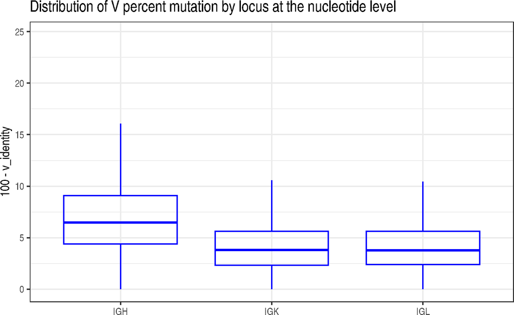

```r
AIRR_df |>
    ggplot(aes(locus, 100 - v_identity)) +
    theme_bw(base_size=14) +
    geom_point(position = position_jitter(width = 0.3), alpha = 0.1) +
    geom_boxplot(color = "blue", fill = NA, outliers = FALSE, alpha = 0.3) +
    ggtitle("Distribution of V percent mutation by locus at the nucleotide level") +
    xlab(NULL)
```

To do the same thing at the amino acid level, we first use the `percent_mutation()` function to compute the percent mutation in the V, D, J segments at the amino acid level:

```r
perc_mut_aa <- percent_mutation(AIRR_df, for.aa=TRUE)
head(perc_mut_aa)
```

```
## # A tibble: 6 × 5
##   sequence_id                    locus v_perc_mut_aa d_perc_mut_aa j_perc_mut_aa
##   <chr>                          <chr>         <dbl>         <dbl>         <dbl>
## 1 heavy_chain_AAACCTGAGAGTACCG-… IGH           16.3            0            0
## 2 light_chain_AAACCTGAGAGTACCG-… IGL           16.7           NA           16.7
## 3 heavy_chain_AAACCTGAGATGGCGT-… IGH            6.06          20            6.25
## 4 light_chain_AAACCTGAGATGGCGT-… IGK            7.37          NA            9.09
## 5 heavy_chain_AAACCTGAGCAGACTG-… IGH           11.3           37.5          6.67
## 6 light_chain_AAACCTGAGCAGACTG-… IGL            4.08          NA            0
```

See `?percent_mutation` for more information.

Then:

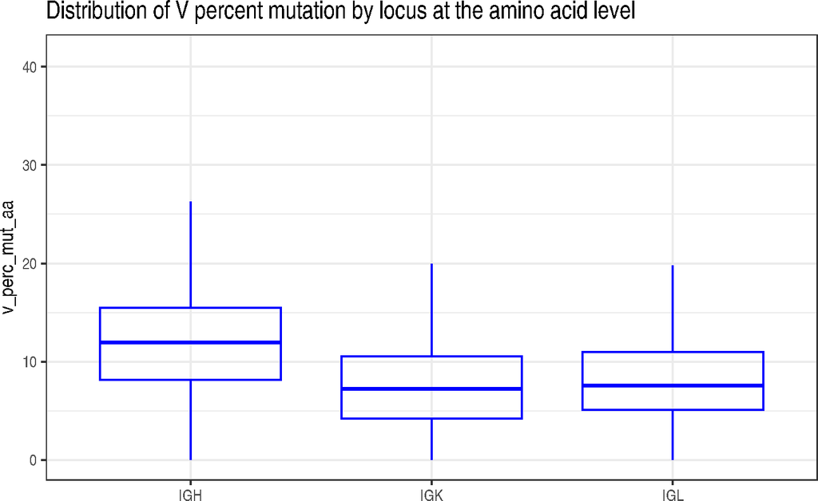

```r
perc_mut_aa |>
    ggplot(aes(locus, v_perc_mut_aa)) +
    theme_bw(base_size=14) +
    geom_point(position = position_jitter(width = 0.3), alpha = 0.1) +
    geom_boxplot(color = "blue", fill = NA, outliers = FALSE, alpha = 0.3) +
    ggtitle("Distribution of V percent mutation by locus at the amino acid level") +
    xlab(NULL)
```

## 8.2 Distribution of germline genes

```r
library(dplyr)
library(scales)
```

Another common analysis is to investigate the distribution of germline genes (e.g., V genes). In this case, we typically stratify the analysis by locus or chain type.

```r
plot_gene_dist <- function(AIRR_df, loc) {
    df_v_gene <- AIRR_df |>
        filter(locus == loc) |>
        mutate(v_gene = allele2gene(v_call)) |>  # drop allele info
        group_by(v_gene) |>
        summarize(n = n(), .groups = "drop") |>
        mutate(frac = n / sum(n))
    df_v_gene |>
        ggplot(aes(frac, v_gene)) +
        theme_bw(base_size=13) +
        geom_col() +
        scale_x_continuous('Percent of sequences', labels = scales::percent) +
        ylab("Germline gene") +
        ggtitle(paste0(loc, "V gene prevalence"))
}
```

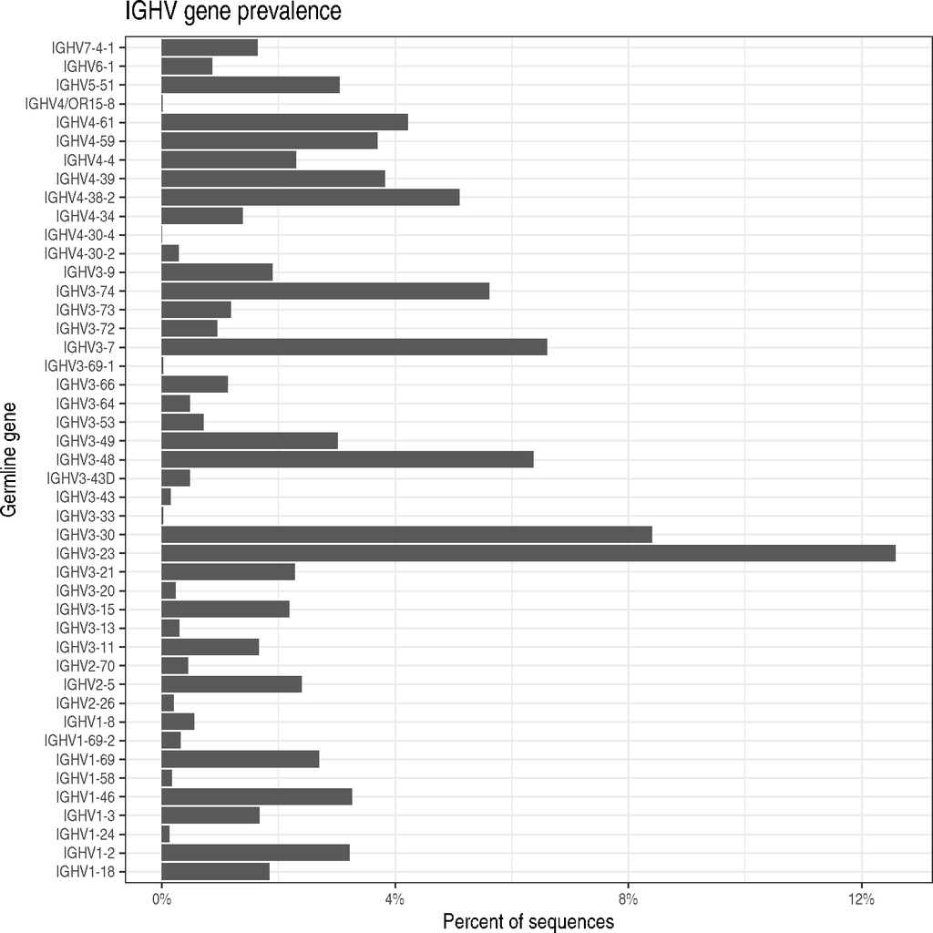

```r
plot_gene_dist(AIRR_df, "IGH")
```

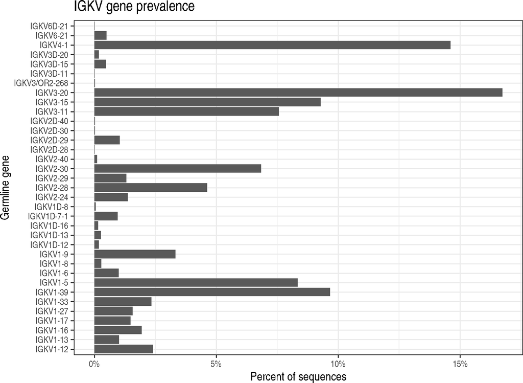

```r
plot_gene_dist(AIRR_df, "IGK")
```

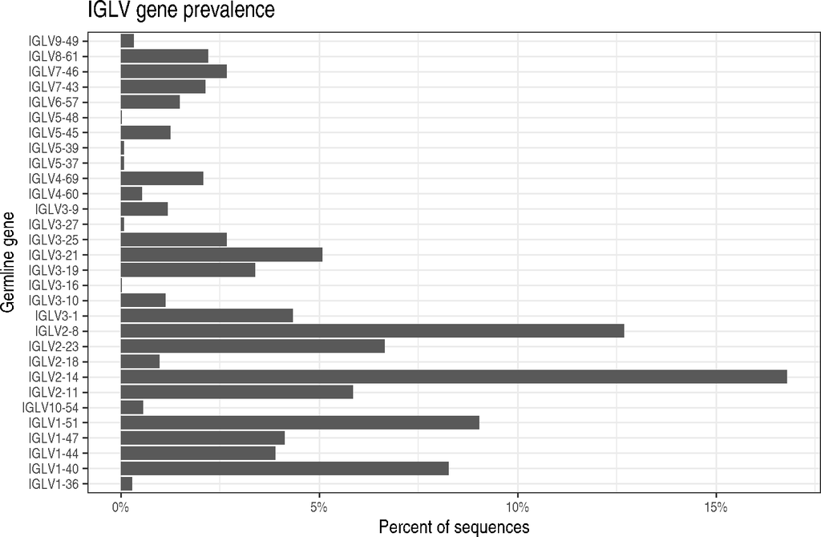

```r
plot_gene_dist(AIRR_df, "IGL")
```

## 8.3 Lengths and motifs of CDR3 sequences

```r
library(ggseqlogo)
```

A third category of analysis focuses on CDR3 sequences, including their lengths and motifs, which are often visualized using sequence logo plots.

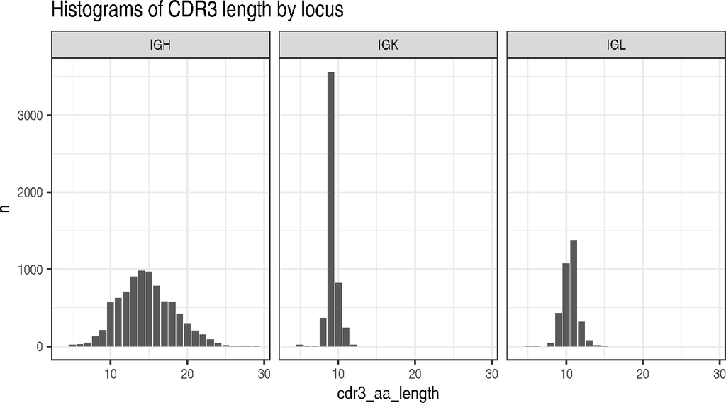

```r
AIRR_df$cdr3_aa_length <- nchar(AIRR_df$cdr3_aa)

AIRR_df |>
    group_by(locus, cdr3_aa_length) |>
    summarize(n = n(), .groups = "drop") |>
    ggplot(aes(cdr3_aa_length, n)) +
    theme_bw(base_size=14) +
    facet_wrap(~locus) +
    geom_col() +
    ggtitle("Histograms of CDR3 length by locus")
```

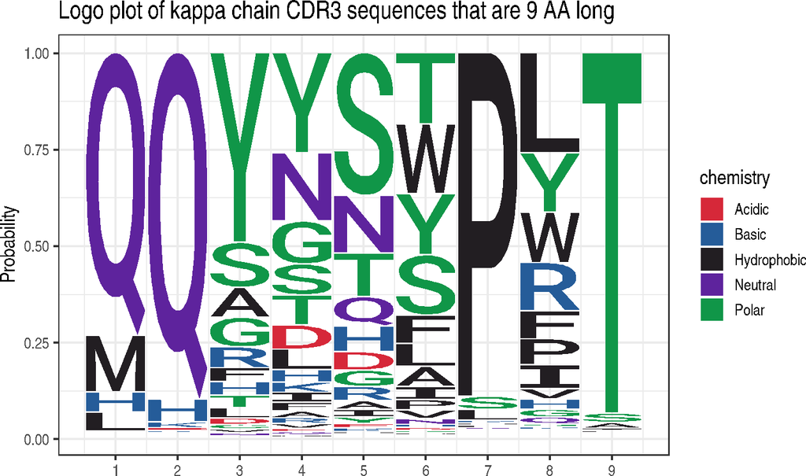

```r
AIRR_df |>
    filter(locus == "IGK", cdr3_aa_length == 9) |>
    pull(cdr3_aa) |>
    ggseqlogo(method = "probability") +
    theme_bw(base_size=14) +
    ggtitle("Logo plot of kappa chain CDR3 sequences that are 9 AA long")
```

# 9 Advanced usage

## 9.1 Passing additional arguments to igblastn()

The `igblastn` *standalone executable* included in IgBLAST supports many command line arguments. You can quickly list them with `igblastn_help()` (or with `igblastn_help(TRUE)` to get an expanded list with more details – see `?igblastn_help`):

```r
igblastn_help()
```

```
## USAGE
##   igblastn [-h] [-help] [-germline_db_V germline_database_name]
##     [-num_alignments_V int_value] [-germline_db_V_seqidlist filename]
##     [-germline_db_D germline_database_name] [-num_alignments_D int_value]
##     [-germline_db_D_seqidlist filename]
##     [-germline_db_J germline_database_name] [-num_alignments_J int_value]
##     [-germline_db_J_seqidlist filename] [-num_alignments_C int_value]
##     [-c_region_db constant_region_database_name]
##     [-custom_internal_data filename] [-d_frame_data filename]
##     [-auxiliary_data filename] [-min_D_match min_D_match]
##     [-V_penalty V_penalty] [-D_penalty D_penalty] [-J_penalty J_penalty]
##     [-num_clonotype num_clonotype] [-clonotype_out clonotype_out]
##     [-allow_vdj_overlap] [-organism germline_origin]
##     [-domain_system domain_system] [-ig_seqtype sequence_type]
##     [-focus_on_V_segment] [-extend_align5end] [-extend_align3end]
##     [-min_V_length Min_V_Length] [-min_J_length Min_J_Length]
##     [-show_translation] [-db database_name] [-dbsize num_letters]
##     [-entrez_query entrez_query] [-query input_file] [-sra accession]
##     [-out output_file] [-evalue evalue] [-word_size int_value]
##     [-gapopen open_penalty] [-gapextend extend_penalty] [-searchsp int_value]
##     [-sum_stats bool_value] [-ungapped] [-lcase_masking] [-query_loc range]
##     [-strand strand] [-parse_deflines] [-outfmt format] [-show_gis]
##     [-num_descriptions int_value] [-num_alignments int_value]
##     [-line_length line_length] [-num_threads int_value] [-remote] [-version]
##
## DESCRIPTION
##    BLAST for Ig and TCR sequences
##
## Use '-help' to print detailed descriptions of command line arguments
```

All these command line arguments can be passed to the `igblastn()` function using the usual `argument_name=argument_value` syntax. For example, command line argument `-num_threads` allows the user to leverage IgBLAST built-in parallel computing capabilities. To use it in `igblastn()`, set argument `num_threads` to the desired value e.g. by calling `igblastn(query, num_threads=8)`.

Note that the Examples section in `?igblastn` provides more information about using `igblastn()` in parallel.

## 9.2 Restrict the search to a subset of user-supplied gene alleles

Some arguments of particular interest are the `germline_db_[VDJ]_seqidlist` arguments. They allow restricting the search of the *germline database* to a list of gene alleles supplied by the user. This list can be provided as a character vector of gene allele identifiers (e.g., `IGHV3-23*01`, `IGHV3-23*04`, etc..), or as the path to a file containing the identifiers (one identifier per line). For example:

```r
V_alleles <- c("IGHV3-23*01", "IGHV3-23*04")
igblastn(query, germline_db_V_seqidlist=V_alleles)
```

If the gene alleles are stored in a file, say in `path/to/my_V_gene_alleles.txt`, then use:

```r
igblastn(query, germline_db_V_seqidlist=file("path/to/my_V_gene_alleles.txt"))
```

Note that in this case, the path to the file containing the gene alleles identifiers must be wrapped in a call to `file()`.

See `?igblastn` for more information.

## 9.3 Combine germline databases from two different organisms

The `combine_germline_dbs()` function can be used to combine two existing *germline databases*, typically (but not necessarily) from two different organisms. This can be useful to analyze BCR sequences from a hybrid organism like a humanized mouse.

To illustrate this, we’re going to analyze BCR sequences from KyDab, the Kymouse Antibody Database: https://kydab.naturalantibody.com/. In Kymab’s Intelliselect Transgenic mouse (Kymouse), a complete set of human variable (V), diversity (D), and junction (J) genes of the IGH locus as well as the V and J genes of the Igλ and Igκ loci were inserted at the sites of the endogenous mouse loci.

### 9.3.1 Prepare the query sequences

We’re going to analyze the Kymouse heavy-chain BCR sequences from the [Influenza #1 Project](https://kydab.naturalantibody.com/influenza-01) from KyDab. The 3,950 heavy-chain BCR sequences from this project are stored in the `Influenza-KV7015_heavy.fasta` file included in *igblastr*:

```r
fasta_file <- "Influenza-KV7015_heavy.fasta"
query <- system.file(package="igblastr", "extdata",
                     "BCR", "KyDab", fasta_file)
```

### 9.3.2 Create the hybrid germline database

For this analysis, we create a hybrid *germline database* by combining *germline databases* from human and mouse. Note that allele names are not unique across species, so we add suffixes to the human and mouse allele names to avoid name clashes (e.g., `IGHV2-5*01_Hs` vs. `IGHV2-5*01_Mm`):

```r
db_name1 <- "IMGT-202614-2.Homo_sapiens.IGH+IGK+IGL"
db_name2 <- install_IMGT_germline_db("202614-2", "Mus_musculus")
```

```
## Germline db IMGT-202614-2.Mus_musculus.IGH+IGK+IGL successfully installed in
## igblastr's persistent cache.
```

```
## Call use_germline_db("IMGT-202614-2.Mus_musculus.IGH+IGK+IGL") to select it as
## the germline db to use with igblastn(). Use list_germline_dbs() to list all the
## germline dbs currently installed in the cache (see '?list_germline_dbs').
```

```r
db_name <- "comb.IMGT-202614-2.human+mouse.IGH+IGK+IGL"
combine_germline_dbs(db_name, db_name1, db_name2,
                     suffix1="_Hs", suffix2="_Mm")
```

Select the new hybrid *germline database* as the database to use with `igblastn()`:

```r
use_germline_db(db_name)

list_germline_dbs()
```

```
##  db_name                                       V   D  J intdata auxdata
##  _OGRDB.human.IGH+IGK+IGL.202410             342  31 23    TRUE    TRUE
##  _OGRDB.human.IGH+IGK+IGL.202410.src         354  33 24    TRUE    TRUE
##  _OGRDB.human.IGH+IGK+IGL.202605             367  31 23    TRUE    TRUE
##  _OGRDB.human.IGH+IGK+IGL.202605.src         379  33 24    TRUE    TRUE
##  _OGRDB.mouse.CAST_EiJ.IGH+IGK+IGL.202603    184   9 22    TRUE    TRUE
##  _OGRDB.mouse.LEWES_EiJ.IGH+IGK+IGL.202603   169  11 22    TRUE    TRUE
##  _OGRDB.mouse.MSM_MsJ.IGH+IGK+IGL.202603     172   9 22    TRUE    TRUE
##  _OGRDB.mouse.NOD_ShiLtJ.IGH+IGK+IGL.202205  149   9 22    TRUE    TRUE
##  _OGRDB.mouse.PWD_PhJ.IGH+IGK+IGL.202410     184  10 22    TRUE    TRUE
##  _OGRDB.rainbow_trout.IGH.202606              81  26 18    TRUE    TRUE
##  _OGRDB.rhesus_monkey.IGH+IGK+IGL.202602    2294  72 39    TRUE    TRUE
##  IMGT-202614-2.Homo_sapiens.IGH+IGK+IGL      730  48 35    TRUE    TRUE
##  IMGT-202614-2.Mus_musculus.IGH+IGK+IGL      865  61 27    TRUE    TRUE
##  comb.IMGT-202614-2.human+mouse.IGH+IGK+IGL 1595 109 62    TRUE    TRUE *
```

### 9.3.3 Call igblastn() on the query sequences

```r
AIRR_df <- igblastn(query, num_alignments_V=1,
                           num_alignments_D=1,
                           num_alignments_J=1)
```

### 9.3.4 A quick look at columns `v_call`, `d_call`, and `j_call`

In the context of this vignette, we’re only going to verify that the Kymouse heavy-chain sequences align to human V, D, and J alleles:

```r
# count_suffixes() assumes suffixes of length 3, e.g. "_Hs"/"_Mm":
count_suffixes <- function(x) {nc <- nchar(x); table(substr(x, nc-2, nc))}

count_suffixes(AIRR_df$v_call)
```

```
##
##  _Hs
## 3950
```

```r
count_suffixes(AIRR_df$d_call)
```

```
##
##  _Hs  _Mm
## 3638  206
```

```r
count_suffixes(AIRR_df$j_call)
```

```
##
##  _Hs
## 3950
```

These counts are plotted in Figure 1 below.

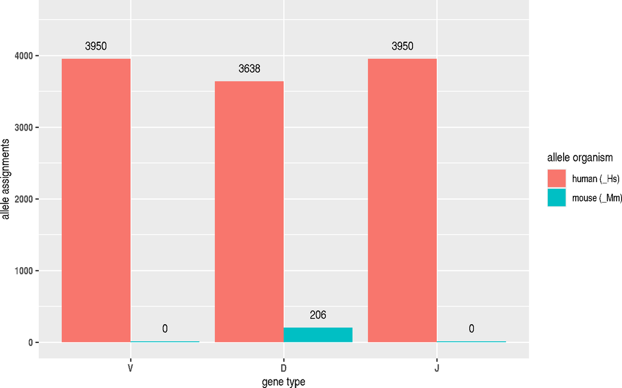

Figure 1: Number of human vs. mouse V/D/J allele assignments  
for the 3,950 Kymouse heavy-chain sequences  
in Influenza-KV7015_heavy.fasta

As expected, all Kymouse heavy-chain sequences align to human V and J alleles. Most also align to human D alleles, with only a small fraction (less than 6%) aligning to mouse D alleles instead.

## 9.4 A TCR analysis example

Even though NCBI IgBLAST primary use case is BCR analysis, it can also be used for TCR sequence analysis, and so does the *igblastr* package.

### 9.4.1 Prepare the TCR query sequences

File `SRR11341217.fasta.gz` included in the package contains 10,875 human beta chain TCR transcripts running from 5’ of reverse transcription reaction to beginning of constant region. See https://www.ncbi.nlm.nih.gov/sra/SRX7944361 for more information about this dataset.

```r
filename <- "SRR11341217.fasta.gz"
query <- system.file(package="igblastr", "extdata", "TCR", filename)
```

### 9.4.2 Install a TCR germline database

To analyze this dataset with `igblastn()`, we need to install and select a human TCR *germline database*. We can use `install_IMGT_germline_db()` with the `tcr.db` argument set to `TRUE` for that. This will install a *germline database* made of the human TCR germline sequences provided by IMGT/V-QUEST:

```r
db_name <- install_IMGT_germline_db("202614-2", organism="Homo sapiens",
                                    tcr.db=TRUE)
```

See the new *germline database* in the list displayed by `list_germline_dbs()`:

```r
list_germline_dbs()
```

```
##  db_name                                       V   D   J intdata auxdata
##  _OGRDB.human.IGH+IGK+IGL.202410             342  31  23    TRUE    TRUE
##  _OGRDB.human.IGH+IGK+IGL.202410.src         354  33  24    TRUE    TRUE
##  _OGRDB.human.IGH+IGK+IGL.202605             367  31  23    TRUE    TRUE
##  _OGRDB.human.IGH+IGK+IGL.202605.src         379  33  24    TRUE    TRUE
##  _OGRDB.mouse.CAST_EiJ.IGH+IGK+IGL.202603    184   9  22    TRUE    TRUE
##  _OGRDB.mouse.LEWES_EiJ.IGH+IGK+IGL.202603   169  11  22    TRUE    TRUE
##  _OGRDB.mouse.MSM_MsJ.IGH+IGK+IGL.202603     172   9  22    TRUE    TRUE
##  _OGRDB.mouse.NOD_ShiLtJ.IGH+IGK+IGL.202205  149   9  22    TRUE    TRUE
##  _OGRDB.mouse.PWD_PhJ.IGH+IGK+IGL.202410     184  10  22    TRUE    TRUE
##  _OGRDB.rainbow_trout.IGH.202606              81  26  18    TRUE    TRUE
##  _OGRDB.rhesus_monkey.IGH+IGK+IGL.202602    2294  72  39    TRUE    TRUE
##  IMGT-202614-2.Homo_sapiens.IGH+IGK+IGL      730  48  35    TRUE    TRUE
##  IMGT-202614-2.Homo_sapiens.TRA+TRB+TRG+TRD  355   6 101    TRUE    TRUE
##  IMGT-202614-2.Mus_musculus.IGH+IGK+IGL      865  61  27    TRUE    TRUE
##  comb.IMGT-202614-2.human+mouse.IGH+IGK+IGL 1595 109  62    TRUE    TRUE *
```

Note that:

- The name of this new *germline database* (`IMGT-202614-2.Homo_sapiens.TRA+TRB+TRG+TRD`) reflects the fact that it contains germline gene alleles from the four T-cell receptor loci: TRA (alpha chain), TRB (beta chain), TRG (gamma chain), and TRD (delta chain).
- This new *germline database* also includes its own *internal data* and *auxiliary data*, as reported in the `intdata` and `auxdata` columns.

See `?install_IMGT_germline_db` and `?list_germline_dbs` for more information.

Let’s select this new database as the *germline database* to use with `igblastn()`:

```r
use_germline_db(db_name)
```

See `?use_germline_db` for more information.

### 9.4.3 Select a TCR constant region database (optional)

Use `list_c_region_dbs()` to list the C-region databases that are available:

```r
list_c_region_dbs()
```

```
##  db_name                                      C
##  _IMGT.human.IGH+IGK+IGL.202605             180 *
##  _IMGT.human.TRA+TRB+TRG+TRD.202605          23
##  _IMGT.mouse.IGH+IGK+IGL.202605              64
##  _IMGT.mouse.TRA+TRB+TRG+TRD.202605          13
##  _IMGT.rabbit.IGH+IGK+IGL.202605             50
##  _IMGT.rabbit.TRA+TRB+TRG+TRD.202605          6
##  _IMGT.rat.IGH+IGK+IGL.202605                25
##  _IMGT.rhesus_monkey.IGH+IGK+IGL.202605      44
##  _IMGT.rhesus_monkey.TRA+TRB+TRG+TRD.202605  10
```

For this analysis of human TCR sequences, we’ll select `_IMGT.human.TRA+TRB+TRG+TRD.202605` as the C-region database to use with `igblastn()`:

```r
use_c_region_db("_IMGT.human.TRA+TRB+TRG+TRD.202605")
```

See `?use_c_region_db` for more information.

### 9.4.4 Call igblastn() on the TCR query sequences

Check the selected databases:

```r
use_germline_db()
```

```
## [1] "IMGT-202614-2.Homo_sapiens.TRA+TRB+TRG+TRD"
```

```r
use_c_region_db()
```

```
## [1] "_IMGT.human.TRA+TRB+TRG+TRD.202605"
```

Call `igblastn()`:

```r
AIRR_df <- igblastn(query)
AIRR_df
```

```
## # A tibble: 10,875 × 111
##    sequence_id    sequence sequence_aa locus stop_codon vj_in_frame v_frameshift
##    <chr>          <chr>    <chr>       <chr> <lgl>      <lgl>       <lgl>
##  1 SRR11341217.1  GTCTCAG… VSDGYSVSRS… TRB   FALSE      TRUE        FALSE
##  2 SRR11341217.2  AATGGGG… DLKNVFPP*A… TRB   TRUE       TRUE        FALSE
##  3 SRR11341217.3  GAGTGGA… SGFVIDKFPI… TRB   FALSE      TRUE        FALSE
##  4 SRR11341217.4  TCTTGAA… LEGFSAQLFP… TRB   FALSE      TRUE        FALSE
##  5 SRR11341217.5  TTACCGA… DLKNVFPP*A… TRB   TRUE       FALSE       FALSE
##  6 SRR11341217.6  GGGGTAC… GYSVSREKKE… TRB   FALSE      TRUE        FALSE
##  7 SRR11341217.7  GCGTGAT… SAEFPKEGPS… TRB   FALSE      TRUE        FALSE
##  8 SRR11341217.8  TGGAGAT… GDIAEGYSVS… TRB   FALSE      TRUE        FALSE
##  9 SRR11341217.9  CACCCAC… DLKNVFPP*A… TRB   TRUE       FALSE       FALSE
## 10 SRR11341217.10 TGATCGG… DRFSAERPKG… TRB   FALSE      TRUE        FALSE
## # ℹ 10,865 more rows
## # ℹ 104 more variables: productive <lgl>, rev_comp <lgl>, complete_vdj <lgl>,
## #   d_frame <lgl>, v_call <chr>, d_call <chr>, j_call <chr>, c_call <chr>,
## #   sequence_alignment <chr>, germline_alignment <chr>,
## #   sequence_alignment_aa <chr>, germline_alignment_aa <chr>,
## #   v_alignment_start <int>, v_alignment_end <int>, d_alignment_start <int>,
## #   d_alignment_end <int>, j_alignment_start <int>, j_alignment_end <int>, …
```

Note that, when using `igblastn()` to analyze TCR sequences, we don’t need to specify the `ig_seqtype` argument like we would have to if we were using the `igblastn` *standalone executable* included in IgBLAST. `igblastn()` will automatically set `ig_seqtype` to `"TCR"` based on the name of the selected *germline database*. See documentation of the `ig_seqtype` argument in `?igblastn` for more information.

# 10 Future developments and session information

## 10.1 Future developments

At the moment, the *igblastr* package does not provide access to the full functionality of the IgBLAST software. Most notably, the `igblastp` *standalone executable* included in IgBLAST has no counterpart in *igblastr*.

Some future developments include:

- Implement `igblastp()`, a wrapper to the `igblastp` *standalone executable* included in IgBLAST for protein-level alignments.
- Add facilities to retrieve arbitrary *germline databases* from OGRDB, the AIRR Community’s Open Germline Receptor Database.